# Worked example of the individual preferences for energy landscape values using the continuous Boyce index

Emilio Berti

I illustrate the P/E curves and the continuous Boyce index with a virtual animal that prefer least-cost paths in the Maunga Whau volcano in Auckland. The volcano raster is provided with the standard datasets in R and can be accessed with `data("volcano")`.

```r
boyce <- function(r, xy, w = 0.1, step = 0.01) {
  vals <- raster::getValues(r) #all cells
  vals <- vals[!is.na(vals)]
  p <- raster::extract(r, xy) #occupied cells
  p <- p[!is.na(p)]
  tot_E <- length(vals)
  tot_P <- length(p)
  min_vals <- min(vals, na.rm = TRUE)
  max_vals <- max(vals, na.rm = TRUE)
  width <- (max_vals - min_vals) * w #windows absolute width
  step_width <- (max_vals - min_vals) * step #step absolute width
  steps <- seq(min_vals, max_vals, by = step_width)
  steps <- steps[1:(length(steps) - 1)] #remove last
  # allocate memory for output
  Fx <- rep(NA, length(steps))
  Fy <- rep(NA, length(steps))
  FracE <- rep(NA, length(steps))
  FracP <- rep(NA, length(steps))
  # calculate
  for (x in steps) {
    i <- which(x == steps)
    P <- sum(p >= x & p < x + width) / tot_P
    E <- sum(vals >= x & vals < x + width) / tot_E
    Fx[i] <- x + width / 2
    Fy[i] <- P / E
    FracE[i] <- E
    FracP[i] <- P
  }
  ans <- data.frame(value = Fx,
                    suitability = Fy,
                    Frac_E = FracE,
                    Frac_P = FracP)
  ans <- ans[ans$value <= max_vals, ]
  return(ans)
}

sign_inversions <- function(x) {
  inv <- sign(x)
  inv <- inv[2:length(x)] != inv[1:(length(x) - 1)]
  inv <- sum(inv)
  return(inv)
}

data("volcano")
```

I estimate the energy landscape for an animal of 1,000 kg. Note that `volcano` does not have a CRS and hence the estimate of energy landscape will not be meaningful outside the scope of this example.

```r
library(raster)
library(enerscape)

r <- raster(volcano)
en <- enerscape(r, 1000, unit = "kcal")
```

```
##  - Raster cells are assumed to have same horizontal and vertical resolution and with planar coordinate reference system (e.g. UTM)
```

```
##   | Calculating slope
```

```
##   | Calculating work
```

```
##   | Calculating conductance (1 / work)
```

```
##  - Do not use slope with negative values for distance calculations
```

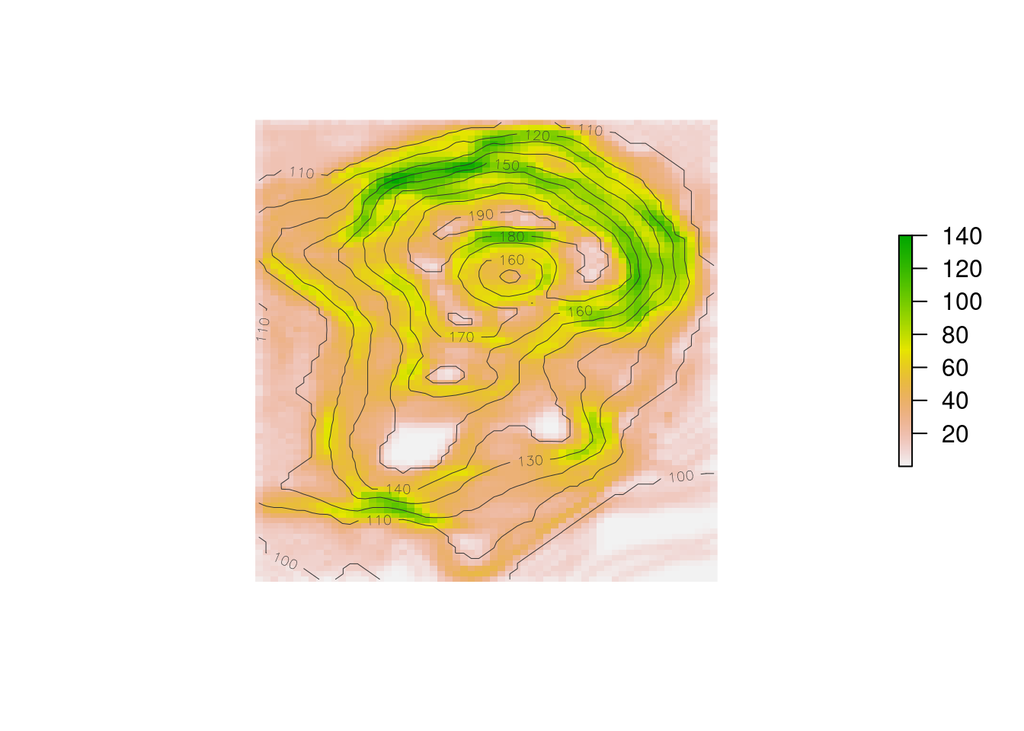

```r
plot(en$rasters$EnergyScape, axes = FALSE, box = FALSE)
contour(r, add = TRUE, lw = 0.5, col = "grey20")
```

I simulate two individuals, one preferring low-cost paths and the other moving in the landscape independently from the energy landscape.

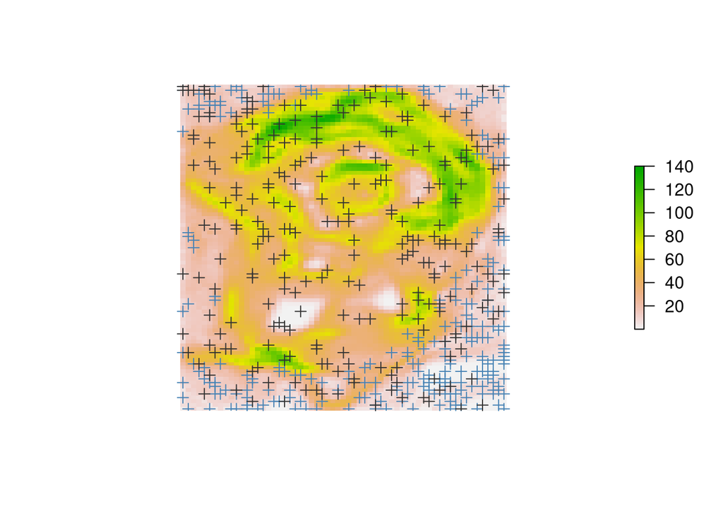

```r
xy <- xyFromCell(r, 1:ncell(r))
energy <- values(r)

ind.1 <- sapply(energy, function(x) ifelse(x > runif(1) * 120, FALSE, TRUE))
ind.1 <- xy[ind.1, ]
ind.2 <- xy[sample(nrow(xy), nrow(ind.1)), ] #same prevalence

plot(en$rasters$EnergyScape, axes = FALSE, box = FALSE)
points(ind.1, pch = 3, col = "steelblue")
points(ind.2, pch = 3, col = "grey20")
```

From the plot of the P/E ratio curves, I can determine if individuals prefer certain energy landscape values different from random, represented by P/E = 1.

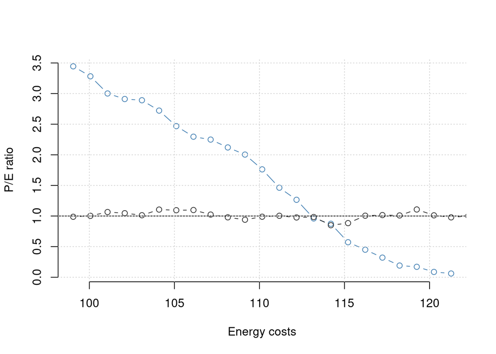

```r
suit.ind.1 <- boyce(r, ind.1)
suit.ind.2 <- boyce(r, ind.2)
# filter out Frac_P < 0.001 to remove cells with very low records
suit.ind.1 <- suit.ind.1[suit.ind.1$Frac_P > 0.001, ]
suit.ind.2 <- suit.ind.2[suit.ind.2$Frac_P > 0.001, ]
# plots
plot(suit.ind.1$value, suit.ind.1$suitability,
     type = "b", frame = FALSE, col = "steelblue",
     xlab = "Energy costs",
     ylab = "P/E ratio")
points(suit.ind.2$value, suit.ind.2$suitability, col = "grey20", type = "b")
abline(h = 1)
grid()
```

The continuous Boyce index for the two individuals is:

```r
ind1.boyce <- cor.test(suit.ind.1$value,
                       suit.ind.1$suitability,
                       method = "spearman")
ind2.boyce <- cor.test(suit.ind.2$value,
                       suit.ind.2$suitability,
                       method = "spearman")
```

The continuous Boyce index show that, as required by how I defined preferences for the individuals, individual one prefer low-cost cells, while individual two use the landscape independently from energy costs. Note that the Spearman’s correlation sometimes finds a significant pattern also where there is not when there are many ties. Inspection of the P/E curve is thus always recommended to properly detect trends. Counting the number of times the P/E curve cross 1 can also provide information on the general trends of animals’ preferences as “wiggliness” of the P/E curve.

```r
res <- rbind(broom::tidy(ind1.boyce), broom::tidy(ind2.boyce))
res <- res[, c("estimate", "p.value")]
res$one_crosses <- c(
  sign_inversions(suit.ind.1$suitability - 1),
  sign_inversions(suit.ind.2$suitability - 1)
)
rownames(res) <- c("Individual.1", "Individual.2")
knitr::kable(res, digits = 2)
```

[output not shown]

Alternatively, as a measure of significance, Kolmogorov-Smirnov test can be performed on the P and E curves.

```r
ind1.p <- ks.test(suit.ind.1$Frac_E, suit.ind.1$Frac_P)$p.value
ind2.p <- ks.test(suit.ind.2$Frac_E, suit.ind.2$Frac_P)$p.value
cat("Individual 1 p-value of E vs P curves: ", round(ind1.p, 3))
```

```
## Individual 1 p-value of E vs P curves:  0
```

```r
cat("Individual 2 p-value of E vs P curves: ", round(ind2.p, 3))
```

```
## Individual 2 p-value of E vs P curves:  0.554
```